# Iteration with Purrr

Joseph Walker

December 13, 2018

# Part 1: Introduction to Purrr

Hello and welcome to the *Iteration with Purrr* tutorial. `Purrr` is a tidyverse package that makes iterating over lists easier and more human readable compared to the base R functions. In the first section, we will learn the principal functions of `purrr` that will allow us to iterate over lists, how to troubleshoot lists, and dive into some more complex examples utilizing other tidyverse principals. In the second section of this tutorial, we will dive into more advanced topics.

```r
library(tidyverse)
library(repurrrsive)

#load the dataset
data("sw_species")

#examine the first element in sw_species
glimpse(sw_species[[2]])
```

```
## List of 15
##  $ name            : chr "Yoda's species"
##  $ classification  : chr "mammal"
##  $ designation     : chr "sentient"
##  $ average_height  : chr "66"
##  $ skin_colors     : chr "green, yellow"
##  $ hair_colors     : chr "brown, white"
##  $ eye_colors      : chr "brown, green, yellow"
##  $ average_lifespan: chr "900"
##  $ homeworld       : chr "http://swapi.co/api/planets/28/"
##  $ language        : chr "Galactic basic"
##  $ people          : chr "http://swapi.co/api/people/20/"
##  $ films           : chr [1:5] "http://swapi.co/api/films/5/" "http://swapi.co/api/films/4/" "http://swapi.co/api/films/6/" "http://swapi.co/api/films/3/" ...
##  $ created         : chr "2014-12-15T12:27:22.877000Z"
##  $ edited          : chr "2014-12-20T21:36:42.148000Z"
##  $ url             : chr "http://swapi.co/api/species/6/"
```

As shown above, we can use double brackets to subset an item or element in a list. In the case of the `sw_species` list, the second element corresponds to another list composed of information for Yoda’s species.

Another way to subset a list is by name using the `$` followed by the *list name*, similar to how we subset dataframes. However, the `sw_species` list is unnamed.

```r
#Get the names of the list elements
names(sw_species)
```

## Mapping

Our first task then will be to apply names to each element using the `$name` subelement from each species sublist. One way to do this is by going through each list individually as so:

```r
#get the name element from the first list in sw_species
(names(sw_species)[[1]] <- sw_species[[1]]$name)
```

```
## [1] "Hutt"
```

```r
#examines the names of the sw_species once again
names(sw_species)
```

```
##  [1] "Hutt" NA     NA     NA     NA     NA     NA     NA     NA     NA
## [11] NA     NA     NA     NA     NA     NA     NA     NA     NA     NA
## [21] NA     NA     NA     NA     NA     NA     NA     NA     NA     NA
## [31] NA     NA     NA     NA     NA     NA     NA
```

This is painstakingly tedious and inefficent. One could use a for loop to do this, but there’s an even better way.

`Purrr` has a `map` function which works similarly to the base R `apply` functions. Map takes a `.x` argument - a vector or list, and a `.f` argument - a function. `Map` acts as a loop iterating the function over each element in the list. Let’s utilize map and the `set_names` function to give the `sw_species` dataset names.

First, we’ll create a list of species names. Map is useful in that the .f argument can be used to subset an element of the list as so:

```r
#create a vector of names of the species
species_names <- map(sw_species, "name")
```

Now we’ll apply the species names to the `sw_species` list.

```r
sw_species <- set_names(sw_species, species_names)

#examine the names of sw_species
names(sw_species)
```

```
##  [1] "Hutt"           "Yoda's species" "Trandoshan"     "Mon Calamari"
##  [5] "Ewok"           "Sullustan"      "Neimodian"      "Gungan"
##  [9] "Toydarian"      "Dug"            "Twi'lek"        "Aleena"
## [13] "Vulptereen"     "Xexto"          "Toong"          "Cerean"
## [17] "Nautolan"       "Zabrak"         "Tholothian"     "Iktotchi"
## [21] "Quermian"       "Kel Dor"        "Chagrian"       "Geonosian"
## [25] "Mirialan"       "Clawdite"       "Besalisk"       "Kaminoan"
## [29] "Skakoan"        "Muun"           "Togruta"        "Kaleesh"
## [33] "Pau'an"         "Wookiee"        "Droid"          "Human"
## [37] "Rodian"
```

```r
#subset one of the lists using the $listelementname
sw_species$Ewok %>%
  simplify()
```

```
##                             name                   classification
##                           "Ewok"                         "mammal"
##                      designation                   average_height
##                       "sentient"                            "100"
##                      skin_colors                      hair_colors
##                          "brown"            "white, brown, black"
##                       eye_colors                 average_lifespan
##                  "orange, brown"                        "unknown"
##                        homeworld                         language
## "http://swapi.co/api/planets/7/"                        "Ewokese"
##                           people                            films
## "http://swapi.co/api/people/30/"   "http://swapi.co/api/films/3/"
##                          created                           edited
##    "2014-12-18T11:22:00.285000Z"    "2014-12-20T21:36:42.155000Z"
##                              url
## "http://swapi.co/api/species/9/"
```

By default, the map function returns elements in the form of a list. However, there are various *flavors* of map which will return different outputs:

| map_* | output |
| --- | --- |
| map_chr() | character vector |
| map_lgl() | logical vector [T or F] |
| map_int() | integer vector |
| map_dbl() | double vector (numeric) |
| map_df() | as data frame |

As an example, let’s use the `map_chr` function to grab the `$language` element from each species list which will return a character vector of the languages. Then we will use this character vector to create a data frame linking the languages back to the names of each species.

In order to do so we need to clarify a few things first:

**To specify how the list is used in the function, use the argument .x to denote where the list element goes inside the function. When you want to use .x to show where the element goes in the function, you need to put a ~ in front of the function in the second argument of map().**

```r
data.frame(culture = map_chr(sw_species, ~.x$language)) %>%
  rownames_to_column(var = "character") %>%
  head(10)
```

```
##         character        culture
## 1            Hutt        Huttese
## 2  Yoda's species Galactic basic
## 3      Trandoshan           Dosh
## 4    Mon Calamari Mon Calamarian
## 5            Ewok        Ewokese
## 6       Sullustan      Sullutese
## 7       Neimodian      Neimoidia
## 8          Gungan   Gungan basic
## 9       Toydarian      Toydarian
## 10            Dug         Dugese
```

## More Complex Operations

### Piping

In the examples above, we saw that it is possible to using piping with the map function. The pipe allows us to streamline our code and makes it more human readable. Here’s another example:

```r
#create a numeric list
(numlist <- list(c(1:10), c(11:20), c(21:30)))
```

```
## [[1]]
##  [1]  1  2  3  4  5  6  7  8  9 10
##
## [[2]]
##  [1] 11 12 13 14 15 16 17 18 19 20
##
## [[3]]
##  [1] 21 22 23 24 25 26 27 28 29 30
```

```r
#use pipes to perform multiple operations
numlist %>%
  map(~.x %>%
      sum %>%
      sqrt %>%
      sin)
```

```
## [[1]]
## [1] 0.9056937
##
## [[2]]
## [1] -0.1162079
##
## [[3]]
## [1] -0.2578112
```

Simple mathematical operations are just the tip of the iceberg to what is possible. In this example, we’ll create some simulated data for housing around the bay area.

```r
#create a list of areas
area <- list("San Francisco", "Oakland", "San Jose")

#create a list of dataframes with simulated housing data for each area
housing_list <- map(area,
                  ~data.frame(area = .x,
                              price = rnorm(mean = 800000,
                                            n = 100,
                                            sd = 800000/2.5),
                              sq_ft = rnorm(mean = 1200,
                                             n = 100,
                                             sd = 1200/4)
                  )
)

#examine a portion of the simulated data
map(.x = housing_list, .f = ~.x %>% head)
```

```
## [[1]]
##            area     price     sq_ft
## 1 San Francisco 1361589.4 1228.1560
## 2 San Francisco  553655.4 1191.1353
## 3 San Francisco  459019.2 1282.6326
## 4 San Francisco  621785.5  880.4739
## 5 San Francisco 1229367.2 1078.8341
## 6 San Francisco  759840.6 1270.8693
##
## [[2]]
##      area     price    sq_ft
## 1 Oakland  290186.8 1151.316
## 2 Oakland 1012691.6 1115.824
## 3 Oakland  983675.7 1560.049
## 4 Oakland  946237.3 1000.224
## 5 Oakland  813243.6 1068.353
## 6 Oakland  661401.9 1109.159
##
## [[3]]
##       area     price     sq_ft
## 1 San Jose  866694.9 1348.5924
## 2 San Jose  859787.0  874.7906
## 3 San Jose  784421.5 1309.6946
## 4 San Jose  668072.6 1467.4857
## 5 San Jose 1006890.6  751.5477
## 6 San Jose  896479.7 1485.4263
```

Now that we have the data let’s model each area using the map function.

```r
#model the data using pipes and the map function
#notice that model function AND the summary function fall within the .f argument of the map function
housing_list %>%
  map(.f = ~.x %>% lm(price ~ sq_ft, data = .) %>% summary)
```

```
## [[1]]
##
## Call:
## lm(formula = price ~ sq_ft, data = .)
##
## Residuals:
##     Min      1Q  Median      3Q     Max
## -762613 -150615  -33117  187999  644973
##
## Coefficients:
##             Estimate Std. Error t value Pr(>|t|)
## (Intercept) 716605.3   136088.0   5.266 8.26e-07 ***
## sq_ft          117.4      111.7   1.051    0.296
## ---
## Signif. codes:  0 '***' 0.001 '**' 0.01 '*' 0.05 '.' 0.1 ' ' 1
##
## Residual standard error: 291700 on 98 degrees of freedom
## Multiple R-squared:  0.01114,    Adjusted R-squared:  0.001048
## F-statistic: 1.104 on 1 and 98 DF,  p-value: 0.296
##
##
## [[2]]
##
## Call:
## lm(formula = price ~ sq_ft, data = .)
##
## Residuals:
##     Min      1Q  Median      3Q     Max
## -927273 -229955   66652  192661  898111
##
## Coefficients:
##             Estimate Std. Error t value Pr(>|t|)
## (Intercept) 593098.2   129483.1   4.581 1.37e-05 ***
## sq_ft          173.0      105.8   1.635    0.105
## ---
## Signif. codes:  0 '***' 0.001 '**' 0.01 '*' 0.05 '.' 0.1 ' ' 1
##
## Residual standard error: 306600 on 98 degrees of freedom
## Multiple R-squared:  0.02655,    Adjusted R-squared:  0.01662
## F-statistic: 2.673 on 1 and 98 DF,  p-value: 0.1053
##
##
## [[3]]
##
## Call:
## lm(formula = price ~ sq_ft, data = .)
##
## Residuals:
##      Min       1Q   Median       3Q      Max
## -1122323  -156487    37947   217910  1038573
##
## Coefficients:
##             Estimate Std. Error t value Pr(>|t|)
## (Intercept) 984708.1   136513.0   7.213 1.16e-10 ***
## sq_ft         -117.8      110.8  -1.063     0.29
## ---
## Signif. codes:  0 '***' 0.001 '**' 0.01 '*' 0.05 '.' 0.1 ' ' 1
##
## Residual standard error: 320500 on 98 degrees of freedom
## Multiple R-squared:  0.01141,    Adjusted R-squared:  0.001319
## F-statistic: 1.131 on 1 and 98 DF,  p-value: 0.2902
```

### multiple lists/datasets

`Purrr` makes it easy to perform function(s) over multiple lists or datasets. For two lists, we can use `map2` which requuires `.x` and `.y` as your list arguments. `pmap` handles more than two lists.

First let’s create a few lists

```r
#create a list of names
names_list <-map(sw_species, .f = ~.$name)

#create a list of lifespans
lifespan_list <- map(sw_species, .f = ~.$average_lifespan)

#create a list of languages
language_list <- map(sw_species, .f = ~.$language)
```

Now let’s create a dataframe using two of the lists

```r
#create a dataframe with the names and lifespan lists
map2_df(.x = names_list, .y = lifespan_list, .f = ~data.frame(names = .x, avg_lifespan = .y))
```

```
##             names avg_lifespan
## 1            Hutt         1000
## 2  Yoda's species          900
## 3      Trandoshan      unknown
## 4    Mon Calamari      unknown
## 5            Ewok      unknown
## 6       Sullustan      unknown
## 7       Neimodian      unknown
## 8          Gungan      unknown
## 9       Toydarian           91
## 10            Dug      unknown
## 11        Twi'lek      unknown
## 12         Aleena           79
## 13     Vulptereen      unknown
## 14          Xexto      unknown
```

[output cut: 23 more lines]

`pmap` works a little differently. First, we need to create a master list, a list of lists so-to-speak.

```r
#create a master list
species_info_list <- list(names = names_list, avg_lifespan = lifespan_list, language = language_list)

pmap_df(.l = species_info_list, .f = function(names, avg_lifespan, language) data.frame(names = names, avg_lifespan = avg_lifespan, language = language))
```

```
##             names avg_lifespan       language
## 1            Hutt         1000        Huttese
## 2  Yoda's species          900 Galactic basic
## 3      Trandoshan      unknown           Dosh
## 4    Mon Calamari      unknown Mon Calamarian
## 5            Ewok      unknown        Ewokese
## 6       Sullustan      unknown      Sullutese
## 7       Neimodian      unknown      Neimoidia
## 8          Gungan      unknown   Gungan basic
## 9       Toydarian           91      Toydarian
## 10            Dug      unknown         Dugese
## 11        Twi'lek      unknown       Twi'leki
## 12         Aleena           79         Aleena
## 13     Vulptereen      unknown     vulpterish
## 14          Xexto      unknown        Xextese
```

[output cut: 23 more lines]

Here’s another example using `pmap`. Notice that we don’t need to use the function argument to define the list elements.

```r
a <- list(1:100)
b <- list(rnorm(10, 25, 2))
c <- list(seq(from = 10, to = 1000, by = 3))

pmap(.l = list(a,b,c), .f = sum)
```

```
## [[1]]
## [1] 172450
```

## Troubleshooting Lists

### Safely

`safely` runs through a list returning result and error components allowing one to pinpoint the issue(s).

```r
#create a list 'foo'
foo <- list(3, -10, Inf, "a")

#use map function on foo
map(foo, log)
```

```
## Error in log(x = x, base = base): non-numeric argument to mathematical function
```

As you see, we get an error somewhere in the list. We know that we can’t take the log of “a”, but what if our list was much larger? It would be very difficult to troubleshoot. This is exactly what `safely` is designed for.

```r
#use safely with map function
map(foo, .f = safely(log, otherwise = NA_real_))
```

```
## [[1]]
## [[1]]$result
## [1] 1.098612
##
## [[1]]$error
## NULL
##
##
## [[2]]
## [[2]]$result
## [1] NaN
##
## [[2]]$error
## NULL
##
##
## [[3]]
## [[3]]$result
## [1] Inf
##
## [[3]]$error
## NULL
##
##
## [[4]]
## [[4]]$result
## [1] NA
##
## [[4]]$error
## <simpleError in log(x = x, base = base): non-numeric argument to mathematical function>
```

It is useful to use the `transpose` function in conjunction with troubleshooting functions such as safely to convert a list of pairs into a pair of lists for easier comprehension.

```r
#use transpose after function to split out results and errors
foo %>%
  map(safely(log, otherwise = NA_real_)) %>%
  transpose()
```

```
## $result
## $result[[1]]
## [1] 1.098612
##
## $result[[2]]
## [1] NaN
##
## $result[[3]]
## [1] Inf
##
## $result[[4]]
## [1] NA
##
##
## $error
## $error[[1]]
## NULL
##
## $error[[2]]
## NULL
##
## $error[[3]]
## NULL
##
## $error[[4]]
## <simpleError in log(x = x, base = base): non-numeric argument to mathematical function>
```

### Possibly

Once we have figured out where the errors exist, we can replace `safely` with `possibly` to implement the change (e.g. inserting an ‘NA’ where all errors occur) without returning the error message.

```r
#use possibly to output list without errors
foo %>%
  map_dbl(possibly(log, otherwise = NA_real_))
```

```
## [1] 1.098612      NaN      Inf       NA
```

Let’s take a look at one more example using the Star Wars Species data we’re already familiar with. Within the species list, there is a height subelement indicating the height of each species in cm. Let’s isolate this element and convert it to feet.

```r
#extract the height subelement
sw_species %>%
  map(~.$average_height) %>%
  map_dbl(as.numeric) %>%
  map_dbl(~.x * 0.0328084, otherwise = NA_real_)
```

```
##           Hutt Yoda's species     Trandoshan   Mon Calamari           Ewok
##       9.842520       2.165354       6.561680       5.249344       3.280840
##      Sullustan      Neimodian         Gungan      Toydarian            Dug
##       5.905512       5.905512       6.233596       3.937008       3.280840
##        Twi'lek         Aleena     Vulptereen          Xexto          Toong
##       6.561680       2.624672       3.280840       4.101050       6.561680
##         Cerean       Nautolan         Zabrak     Tholothian       Iktotchi
##       6.561680       5.905512       5.905512             NA       5.905512
##       Quermian        Kel Dor       Chagrian      Geonosian       Mirialan
##       7.874016       5.905512       6.233596       5.839895       5.905512
##       Clawdite       Besalisk       Kaminoan        Skakoan           Muun
##       5.905512       5.839895       7.217848             NA       6.233596
##        Togruta        Kaleesh         Pau'an        Wookiee          Droid
##       5.905512       5.577428       6.233596       6.889764             NA
##          Human         Rodian
##       5.905512       5.577428
```

### Walk

The `walk` function makes list outputs more human readable. It calls the function (.f) for its ‘side-effect’ and returns the input (.x) removing all the unnecessary list bracketing.

In the example below we’ll use the `population` dataset from the `tidyr` package to plot year vs. population for a selection of countries.

```r
#select a random sample of countries
(countries <- unique(population$country) %>%
  sample(size = 5))
```

```
## [1] "Saint Lucia"                       "Costa Rica"
## [3] "Luxembourg"                        "Bonaire, Saint Eustatius and Saba"
## [5] "Cyprus"
```

[figure not shown]

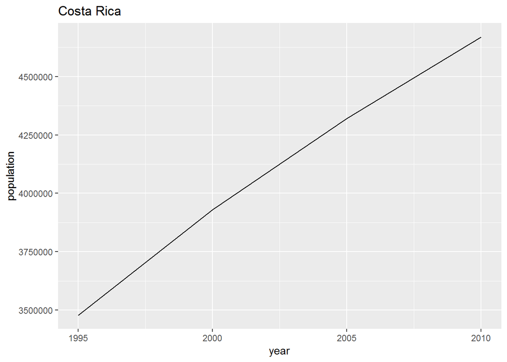

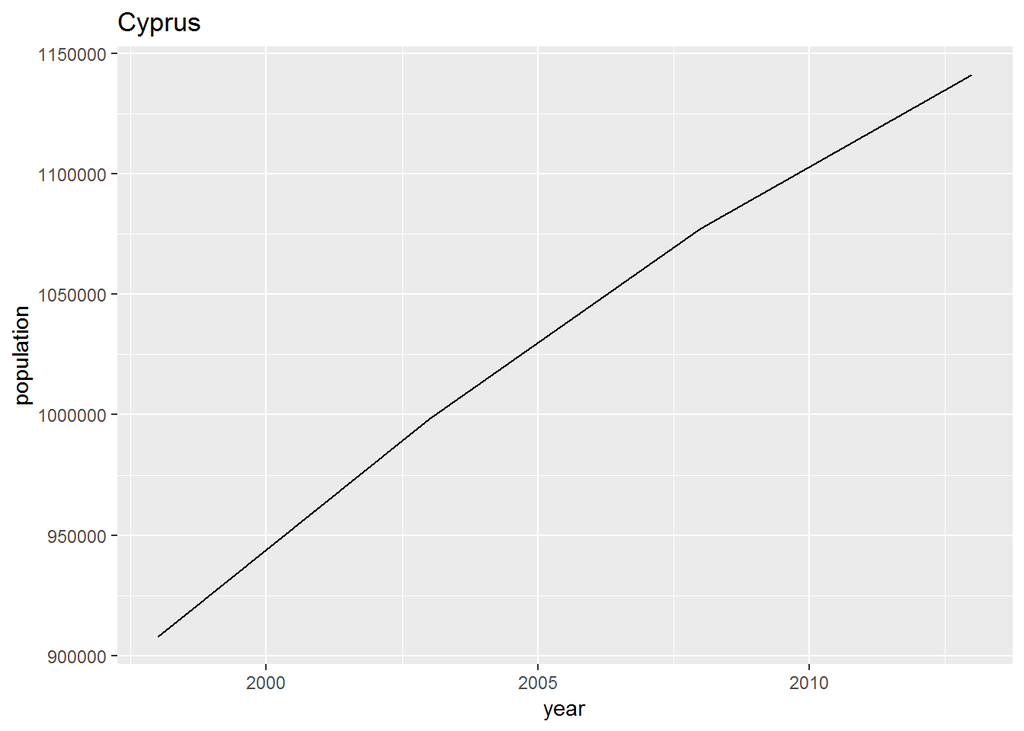

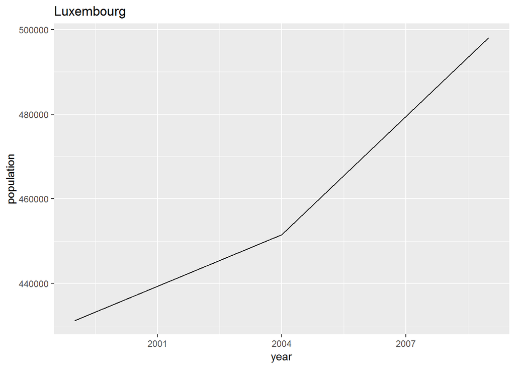

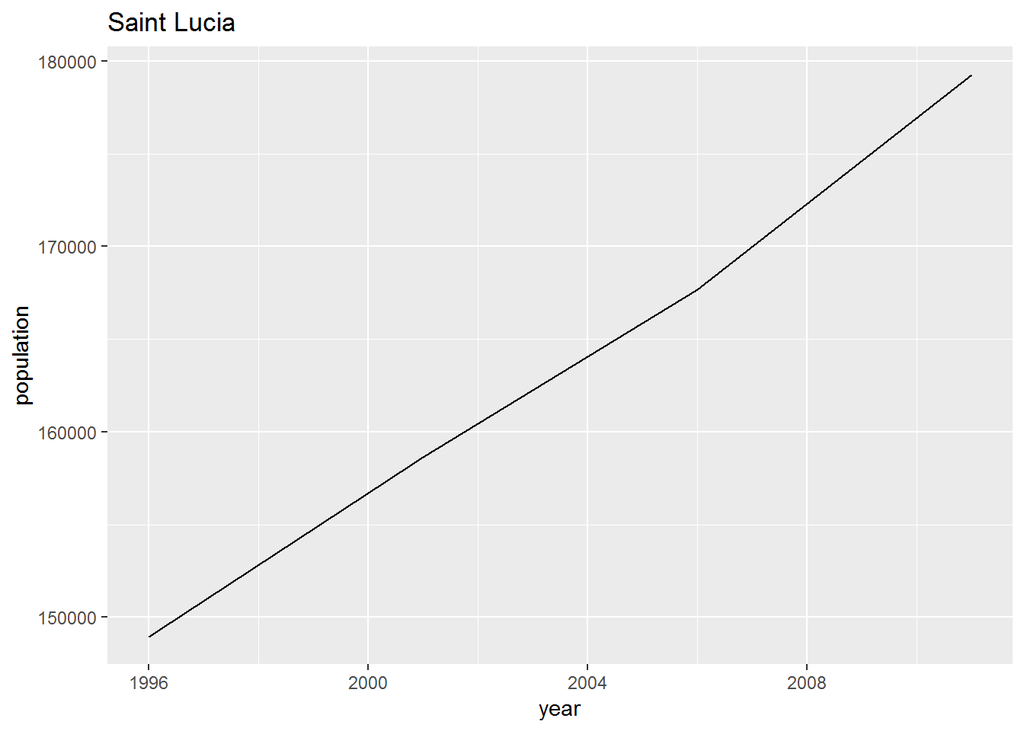

```r
plots <- population %>%
  filter(country == countries) %>% # filter only countries of interest
  split(.$country) %>% # split the data by country
  map2(.x = .,
       .y = names(.),
       .f = ~ggplot(.x, aes(x = year, y = population)) +
         geom_line() +
         labs(title = .y))

walk(plots, print)
```

## Problem Solving

Now that we have some experience working with various functions in R, let’s put our new found skills to the test by solving some problems. The `gh_users` dataset is also from the `repurrrsive` package and provides some data on github users.

First, let’s take a look at the dataset.

```r
#summarize the dataset
summary(gh_users)
```

```
##      Length Class  Mode
## [1,] 30     -none- list
## [2,] 30     -none- list
## [3,] 30     -none- list
## [4,] 30     -none- list
## [5,] 30     -none- list
## [6,] 30     -none- list
```

```r
#determine whether the dataset is named
names(gh_users)
```

The `gh_users` daatset is comprised of 6 lists each comprised of 30 elements. We also know that the lists do not contain names. Let’s take a look at the elements from the first list to see what kind of information is included.

```r
#exmaine the structure of the first list
str(gh_users[[1]])
```

```
## List of 30
##  $ login              : chr "gaborcsardi"
##  $ id                 : int 660288
##  $ avatar_url         : chr "https://avatars.githubusercontent.com/u/660288?v=3"
##  $ gravatar_id        : chr ""
##  $ url                : chr "https://api.github.com/users/gaborcsardi"
##  $ html_url           : chr "https://github.com/gaborcsardi"
##  $ followers_url      : chr "https://api.github.com/users/gaborcsardi/followers"
##  $ following_url      : chr "https://api.github.com/users/gaborcsardi/following{/other_user}"
##  $ gists_url          : chr "https://api.github.com/users/gaborcsardi/gists{/gist_id}"
##  $ starred_url        : chr "https://api.github.com/users/gaborcsardi/starred{/owner}{/repo}"
##  $ subscriptions_url  : chr "https://api.github.com/users/gaborcsardi/subscriptions"
##  $ organizations_url  : chr "https://api.github.com/users/gaborcsardi/orgs"
##  $ repos_url          : chr "https://api.github.com/users/gaborcsardi/repos"
##  $ events_url         : chr "https://api.github.com/users/gaborcsardi/events{/privacy}"
```

[output cut: 16 more lines]

Now, let’s determine which of the users has the most public repositories.

```r
map_int(gh_users, ~.$public_repos) %>% #pull out the # of public repositories
  set_names(map_chr(gh_users, ~.$name)) %>% #assign names to each list element
  sort(decreasing = T) #sort the data
```

```
## Jennifer (Jenny) Bryan       Thomas J. Leeper                Jeff L.
##                    168                     99                     67
##           Gábor Csárdi          Maëlle Salmon            Julia Silge
##                     52                     31                     26
```

And there you have it. Jennifer Bryan has the most repositories with a whopping 168.

Now let’s take a look at an intersting problem using the `sw_films` and `sw_people` data.

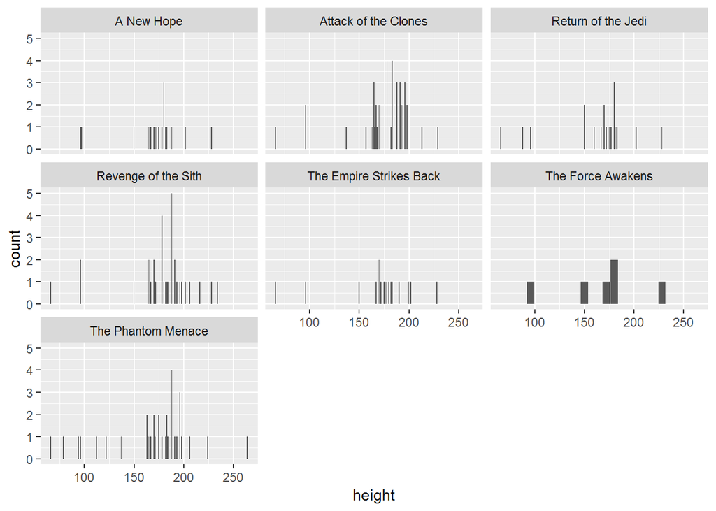

```r
# Turn data into correct dataframe format
film_by_character <- tibble(filmtitle = map_chr(sw_films, ~.$title)) %>%
    mutate(filmtitle, characters = map(sw_films, ~.$characters)) %>%
    unnest()

# Pull out elements from sw_people
sw_characters <- map_df(sw_people, `[`, c("height", "mass", "name", "url"))

# Join the two new objects
character_data <- inner_join(film_by_character, sw_characters, by = c("characters" = "url")) %>%
    # Make sure the columns are numbers
    mutate(height = as.numeric(height), mass = as.numeric(mass))

# Plot the heights, faceted by film title
ggplot(character_data, aes(x = height)) +
  geom_histogram(stat = "count") +
  facet_wrap(~ filmtitle)
```

# Part 2

## Mappers

A classical function is also known as a *lambda* or *anonymous* function because it is unnamed and created in the context of the iteration.

There are three main advantages to using mappers:

- concise
- easy to read
- reusable

Mappers take on a one-sided formula. We use a ~ followed by the formula and a `.x` to refer to the list input we want to iterate over in the function. We can also use a single dot `.` or `..1` in place of `.x`.

Here’s an example using the list *numlist* we created earlier in the tutorial.

```r
#examine the list 'numlist'
str(numlist)
```

```
## List of 3
##  $ : int [1:10] 1 2 3 4 5 6 7 8 9 10
##  $ : int [1:10] 11 12 13 14 15 16 17 18 19 20
##  $ : int [1:10] 21 22 23 24 25 26 27 28 29 30
```

```r
#a simple map function
map(numlist, mean)
```

```
## [[1]]
## [1] 5.5
##
## [[2]]
## [1] 15.5
##
## [[3]]
## [1] 25.5
```

```r
# mapper with .
map(numlist, ~ mean(.) + 2)
```

```
## [[1]]
## [1] 7.5
##
## [[2]]
## [1] 17.5
##
## [[3]]
## [1] 27.5
```

```r
# mapper with ..1
map(numlist, ~ mean(..1) %>% sqrt)
```

```
## [[1]]
## [1] 2.345208
##
## [[2]]
## [1] 3.937004
##
## [[3]]
## [1] 5.049752
```

It is good practice to write a function for anything you have to do more than twice.

Let’s suppose the list *numlist* is temeprature readings in celsius and we want to convert them to farenheit.

```r
# create a function to convert celsius to farnehit
c_to_f <- function(x){
  (x * 9/5) + 32
}

#iterate over numlist with c_to_f function
map(.x = numlist, .f = c_to_f)
```

```
## [[1]]
##  [1] 33.8 35.6 37.4 39.2 41.0 42.8 44.6 46.4 48.2 50.0
##
## [[2]]
##  [1] 51.8 53.6 55.4 57.2 59.0 60.8 62.6 64.4 66.2 68.0
##
## [[3]]
##  [1] 69.8 71.6 73.4 75.2 77.0 78.8 80.6 82.4 84.2 86.0
```

We can also create a mapper using the `as_mapper` function which requires less code.

```r
#create c_to_f function using as_mapper
c_to_f <- as_mapper(~ (.x * 9/5) + 32)

#iterate over numlist with mapper function
map(.x = numlist, .f = c_to_f)
```

```
## [[1]]
##  [1] 33.8 35.6 37.4 39.2 41.0 42.8 44.6 46.4 48.2 50.0
##
## [[2]]
##  [1] 51.8 53.6 55.4 57.2 59.0 60.8 62.6 64.4 66.2 68.0
##
## [[3]]
##  [1] 69.8 71.6 73.4 75.2 77.0 78.8 80.6 82.4 84.2 86.0
```

## Cleaning Data with Mappers & Predicates

**80% of data science is cleaning the data. It’s not glamarous, but it’s the truth.**

When dealing with lists, there are a few useful functions we can utilize in conjunction with mappers to help us clean up the data. We’ll refer to these **predicates**.

Predicate functions are those which test a condition and return either **True** or **False**. `is.numeric` is an example of a predicate function; so are `>`, `<`, and `==` operators.

On the other hand, *predicate functionals* take an object and a predicate function and return some value. `keep`, `discard`, `every`, and `some` are examples of predicate functionals avaliable in `purrr`.

### Keep & Discard

As the name suggests `keep` is a logical function which will return any data in which the condition is met. `Discard` will do the opposite.

```r
#examine foo
foo
```

```
## [[1]]
## [1] 3
##
## [[2]]
## [1] -10
##
## [[3]]
## [1] Inf
##
## [[4]]
## [1] "a"
```

```r
#keep character elements
keep(foo, is.character)
```

```
## [[1]]
## [1] "a"
```

Let’s take a look at a more complex example. We’ll use the `sw_species` list again. Here, we want to discard any species whose lifespan is unknown.

```r
discard(sw_species, ~.x$average_lifespan == 'unknown') %>%
  map("average_lifespan") %>%
  simplify()
```

```
##           Hutt Yoda's species      Toydarian         Aleena       Nautolan
##         "1000"          "900"           "91"           "79"           "70"
##       Quermian        Kel Dor       Clawdite       Besalisk       Kaminoan
##           "86"           "70"           "70"           "75"           "80"
##           Muun        Togruta        Kaleesh         Pau'an        Wookiee
##          "100"           "94"           "80"          "700"          "400"
##          Droid          Human
##   "indefinite"          "120"
```

Predicate functions work well in conjunction with mappers as in the following example:

```r
#examine numlist
numlist
```

```
## [[1]]
##  [1]  1  2  3  4  5  6  7  8  9 10
##
## [[2]]
##  [1] 11 12 13 14 15 16 17 18 19 20
##
## [[3]]
##  [1] 21 22 23 24 25 26 27 28 29 30
```

```r
#mapper for divisible by three
divisible_by_three <- as_mapper(~.x %% 3 == 0)

#map over numlist applying keep and mapper function
map(numlist, ~keep(.x, divisible_by_three))
```

```
## [[1]]
## [1] 3 6 9
##
## [[2]]
## [1] 12 15 18
##
## [[3]]
## [1] 21 24 27 30
```

## Writing cleaner code

As we’ve seen so far, `purrr` is a useful package for writing cleaner code and offers the following advantages:

- light - less code written overall
- readable - less repetition, focus on what’s being executed
- interpretable - code becomes more specific and easier to understand in the long run
- maintainable - easier to fix if errors arise

### Compose & Partial

The `compose` function allows us to utilize multiple functions. The caveat is that functions are applied right to left within the function itself.

The `partial` function allows us to write a function in which we specify some of the arguments. This could be useful if we know we’ll be using a function repeatedly on different datasets where most of the arguments will remain the same.

We’ll take a look at the housing_list data we created earlier in this tutorial. First, let’s summarize the data to see what we’re working with.

```r
#summary of housing_list
map(housing_list, summary)
```

```
## [[1]]
##             area         price             sq_ft
##  San Francisco:100   Min.   :  37553   Min.   : 552.5
##                      1st Qu.: 707458   1st Qu.: 968.8
##                      Median : 853474   Median :1193.4
##                      Mean   : 856264   Mean   :1189.5
##                      3rd Qu.:1058931   3rd Qu.:1373.3
##                      Max.   :1556170   Max.   :1818.3
##
## [[2]]
##       area         price             sq_ft
##  Oakland:100   Min.   : -43606   Min.   : 388.1
##                1st Qu.: 566412   1st Qu.:1007.6
##                Median : 851083   Median :1134.9
##                Mean   : 798772   Mean   :1189.1
##                3rd Qu.: 985728   3rd Qu.:1371.8
##                Max.   :1746262   Max.   :1915.5
##
## [[3]]
##        area         price             sq_ft
##  San Jose:100   Min.   :-334290   Min.   : 356.6
##                 1st Qu.: 666797   1st Qu.: 995.6
##                 Median : 869930   Median :1236.0
##                 Mean   : 843601   Mean   :1197.8
##                 3rd Qu.:1041880   3rd Qu.:1415.7
##                 Max.   :1886953   Max.   :1749.7
```

Oddly enough, it appears there are some houses with negative prices. This doesn’t make sense. Let’s create a `partial` function that discards negative values.

```r
#partial function to discard negatives
discard_negatives <- partial(discard, .p = ~.x < 0)
```

I can’t quite use the function by itself because the housing_list is a list of dataframes and the discard function works elementwise on lists. Luckily, there’s a function which will help get the data into the format we need. `Flatten` will take each column and convert it into an element wise list.

```r
#compose a function that will flatten the data,
#discard the negatives,
#and finally takes the mean of each list
get_means <- compose(round, mean, discard_negatives)

housing_list %>%
  set_names(area) %>%
  transpose() %>%
  map(. %>% map(get_means)) %>%
  map(flatten_df)
```

```
## $area
## # A tibble: 1 x 3
##   `San Francisco` Oakland `San Jose`
##             <dbl>   <dbl>      <dbl>
## 1              NA      NA         NA
##
## $price
## # A tibble: 1 x 3
##   `San Francisco` Oakland `San Jose`
##             <dbl>   <dbl>      <dbl>
## 1          856264  807281     855499
##
## $sq_ft
## # A tibble: 1 x 3
##   `San Francisco` Oakland `San Jose`
##             <dbl>   <dbl>      <dbl>
## 1            1190    1189       1198
```

## Putting It All Together

Here’s one final example in which we’ll nest a dataframe, model each group and plot the data. Thanks to the efficiency of `purrr` this complex set of operations takes only a few lines of code to complete!

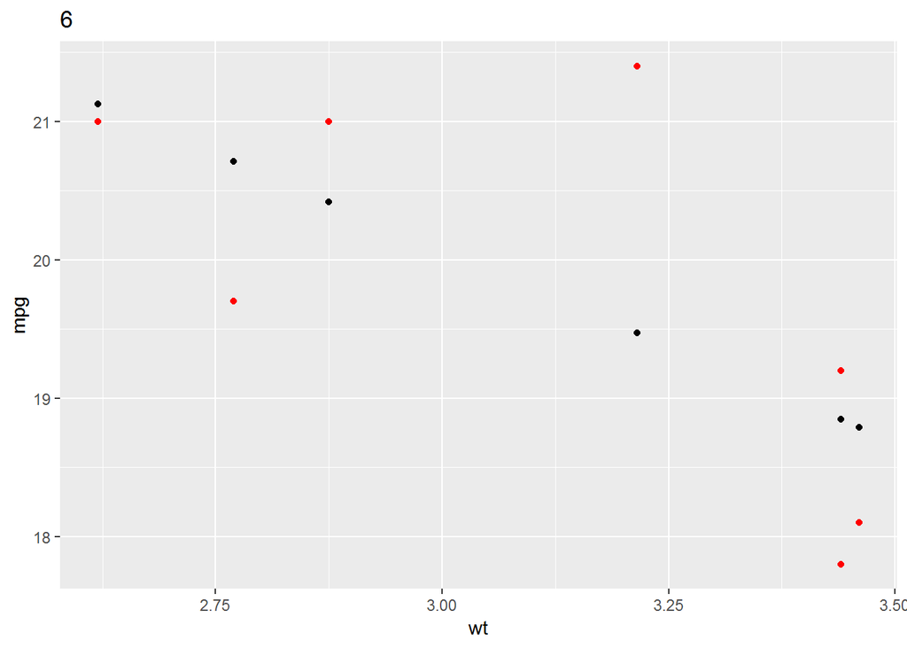

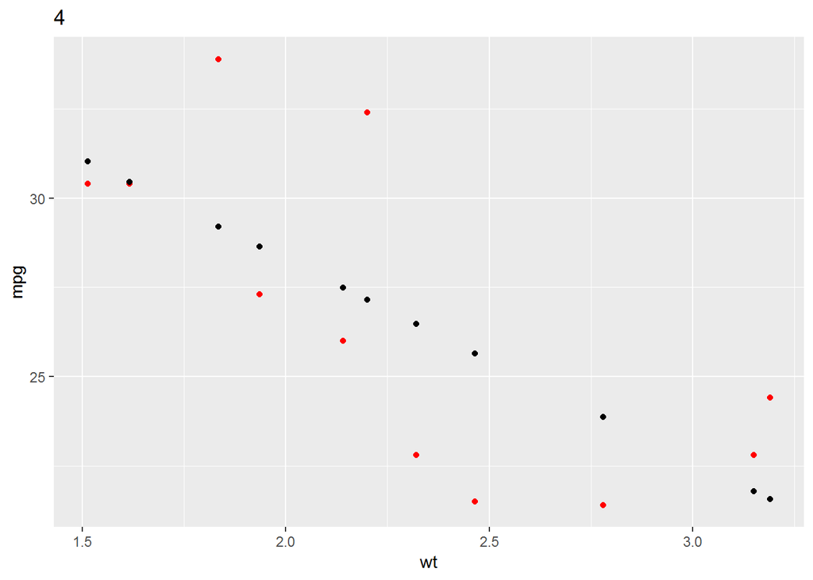

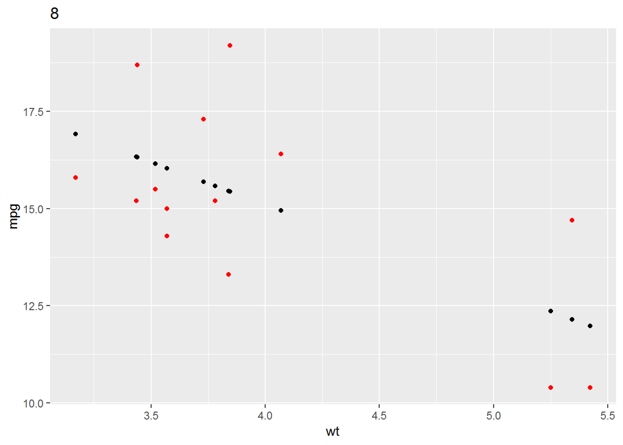

```r
library(modelr)

#compose the function
group_nest <- compose(nest, group_by)

nested_data <- group_nest(mtcars, cyl)

model1 <- function(x){
  lm(mpg ~ wt, data = x)
}


nested_data %>%
  mutate(model = map(data, model1)) %>%
  mutate(pred = map2(data, model, add_predictions)) %>%
  map2(.x = .$pred,
       .y = .$cyl,
       .f = ~ggplot(.x,)+
         geom_point(aes(x = wt, y = mpg), color = "red")+
         geom_point(aes(x = wt, y = pred), color = "black") +
         labs(title = .y)) %>%
  walk(print)
```